# (13776) MODELIZACIÓN ESTADÍSTICA [22-23]

Tarea: Modelos aditivos generalizados

Daniel Silva Gomes de Araújo

2023

# PRÁCTICA

```r
poi <- read.csv("C:/Users/dgoma/Downloads/POI.txt", sep="")
library(mgcv)
fit.gam <- gam(poi$poi ~ s(poi$gluc,k=25,bs="ps"),method="REML",select="FALSE")
summary(fit.gam)
```

```
#>
#> Family: gaussian
#> Link function: identity
#>
#> Formula:
#> poi$poi ~ s(poi$gluc, k = 25, bs = "ps")
#>
#> Parametric coefficients:
#>             Estimate Std. Error t value Pr(>|t|)
#> (Intercept) 0.197363   0.008037   24.56   <2e-16 ***
#> ---
#> Signif. codes:  0 '***' 0.001 '**' 0.01 '*' 0.05 '.' 0.1 ' ' 1
#>
#> Approximate significance of smooth terms:
#>               edf Ref.df     F p-value
#> s(poi$gluc) 6.014  7.437 13.81  <2e-16 ***
#> ---
#> Signif. codes:  0 '***' 0.001 '**' 0.01 '*' 0.05 '.' 0.1 ' ' 1
#>
#> R-sq.(adj) =  0.0417   Deviance explained = 4.41%
#> -REML = 1131.1  Scale est. = 0.15187   n = 2351
```

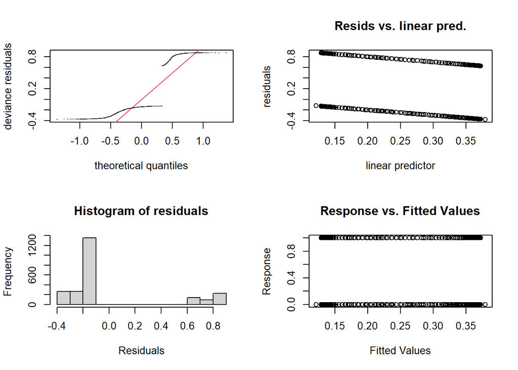

```
#>
#> Method: REML   Optimizer: outer newton
#> full convergence after 6 iterations.
#> Gradient range [-3.073481e-06,7.015463e-08]
#> (score 1131.074 & scale 0.1518716).
#> Hessian positive definite, eigenvalue range [1.88912,1174.505].
#> Model rank =  25 / 25
#>
#> Basis dimension (k) checking results. Low p-value (k-index<1) may
#> indicate that k is too low, especially if edf is close to k'.
#>
#>                k'   edf k-index p-value
#> s(poi$gluc) 24.00  6.01    0.36  <2e-16 ***
#> ---
#> Signif. codes:  0 '***' 0.001 '**' 0.01 '*' 0.05 '.' 0.1 ' ' 1
```

```r
gam.check(fit.gam)
```

2. Evalua el posible efecto de la glucosa preoperatoria (`gluc`) y la presencia de diabetes (`diab`), sobre la presencia de infección post-operatoria (`poi`).
- Ajusta un modelo gam, obtén un del ajuste y gráficos de efectos. Comenta los resultados.
- ¿es el efecto de diabetes significativo?. ¿Qué modelo es mejor, con o sin diabetes?

```r
poi <- read.csv("C:/Users/dgoma/Downloads/POI.txt", sep="")
library(mgcv)
gam1 <- gam(poi$poi ~ poi$diab + s(poi$gluc,k=25,bs="ps"),method="REML", select=TRUE)
summary(gam1)
```

```
#>
#> Family: gaussian
#> Link function: identity
#>
#> Formula:
#> poi$poi ~ poi$diab + s(poi$gluc, k = 25, bs = "ps")
#>
#> Parametric coefficients:
#>             Estimate Std. Error t value Pr(>|t|)
#> (Intercept)  0.19477    0.00834  23.355   <2e-16 ***
#> poi$diab     0.04289    0.03695   1.161    0.246
#> ---
#> Signif. codes:  0 '***' 0.001 '**' 0.01 '*' 0.05 '.' 0.1 ' ' 1
#>
#> Approximate significance of smooth terms:
#>               edf Ref.df     F p-value
#> s(poi$gluc) 5.115     24 3.752  <2e-16 ***
#> ---
#> Signif. codes:  0 '***' 0.001 '**' 0.01 '*' 0.05 '.' 0.1 ' ' 1
#>
#> R-sq.(adj) =  0.0421   Deviance explained = 4.46%
#> -REML = 1132.4  Scale est. = 0.15181   n = 2351
```

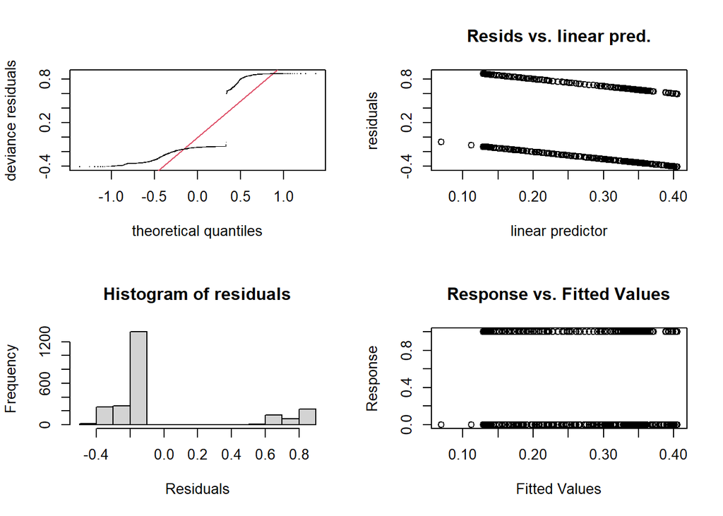

```
#>
#> Method: REML   Optimizer: outer newton
#> full convergence after 6 iterations.
#> Gradient range [-4.609717e-05,1.636202e-07]
#> (score 1132.376 & scale 0.1518063).
#> Hessian positive definite, eigenvalue range [4.609292e-05,1174.506].
#> Model rank =  26 / 26
#>
#> Basis dimension (k) checking results. Low p-value (k-index<1) may
#> indicate that k is too low, especially if edf is close to k'.
#>
#>                k'   edf k-index p-value
#> s(poi$gluc) 24.00  5.11    0.36  <2e-16 ***
#> ---
#> Signif. codes:  0 '***' 0.001 '**' 0.01 '*' 0.05 '.' 0.1 ' ' 1

# La presencia de diabetes no es significativa mientras que el efecto de la glucosa preoperatoria es significativo sobre la presencia de infección posrespiratoria.
```

```r
gam.check(gam1)
```

- ¿es el efecto de diabetes significativo?. ¿Qué modelo es mejor, con o sin diabetes?

```r
# El efecto de diabetes no es significativo.

poi <- read.csv("C:/Users/dgoma/Downloads/POI.txt", sep="")
library(mgcv)
gam1 <- gam(poi$poi ~ poi$diab + s(poi$gluc,k=25,bs="ps"),method="REML", select=TRUE)
summary(gam1)
```

```
#>
#> Family: gaussian
#> Link function: identity
#>
#> Formula:
#> poi$poi ~ poi$diab + s(poi$gluc, k = 25, bs = "ps")
#>
#> Parametric coefficients:
#>             Estimate Std. Error t value Pr(>|t|)
#> (Intercept)  0.19477    0.00834  23.355   <2e-16 ***
#> poi$diab     0.04289    0.03695   1.161    0.246
#> ---
#> Signif. codes:  0 '***' 0.001 '**' 0.01 '*' 0.05 '.' 0.1 ' ' 1
#>
#> Approximate significance of smooth terms:
#>               edf Ref.df     F p-value
#> s(poi$gluc) 5.115     24 3.752  <2e-16 ***
#> ---
#> Signif. codes:  0 '***' 0.001 '**' 0.01 '*' 0.05 '.' 0.1 ' ' 1
#>
#> R-sq.(adj) =  0.0421   Deviance explained = 4.46%
#> -REML = 1132.4  Scale est. = 0.15181   n = 2351
```

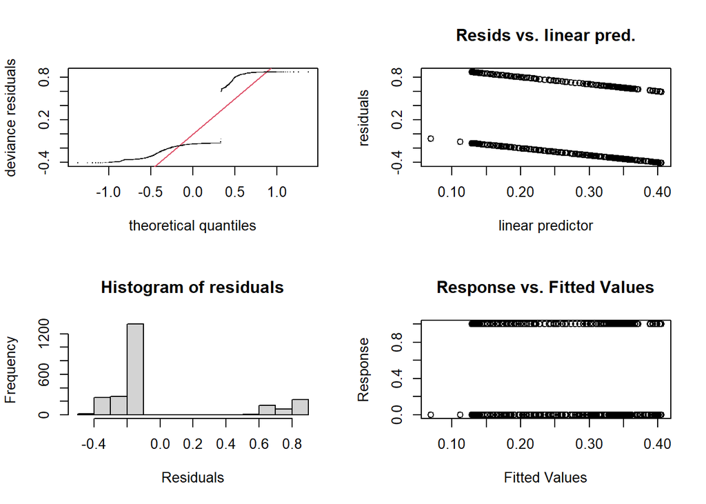

[output not shown]

```r
gam.check(gam1)
```

- Ajusta el modelo incorporando la intersección entre glucosa y diabetes. Obtener un resumen del ajuste y el gráfico del efecto de la glucosa. Comenta los resultados

```r
poi <- read.csv("C:/Users/dgoma/Downloads/POI.txt", sep="")
library(mgcv)
gam3 <- gam(poi$poi ~ poi$diab + s(poi$gluc,k=25,bs="ps") +
              s(poi$gluc,k=25,bs="ps",by=poi$diab),method="REML",select=TRUE)
summary(gam3)
```

```
#>
#> Family: gaussian
#> Link function: identity
#>
#> Formula:
#> poi$poi ~ poi$diab + s(poi$gluc, k = 25, bs = "ps") + s(poi$gluc,
#>     k = 25, bs = "ps", by = poi$diab)
#>
#> Parametric coefficients:
#>             Estimate Std. Error t value Pr(>|t|)
#> (Intercept) 0.195437   0.008338  23.440   <2e-16 ***
#> poi$diab    0.102559   0.086247   1.189    0.235
#> ---
#> Signif. codes:  0 '***' 0.001 '**' 0.01 '*' 0.05 '.' 0.1 ' ' 1
#>
#> Approximate significance of smooth terms:
#>                        edf Ref.df     F p-value
#> s(poi$gluc)          4.998     24 4.040 < 2e-16 ***
#> s(poi$gluc):poi$diab 2.082     23 0.337 0.00777 **
#> ---
#> Signif. codes:  0 '***' 0.001 '**' 0.01 '*' 0.05 '.' 0.1 ' ' 1
#>
#> R-sq.(adj) =  0.0452   Deviance explained = 4.85%
#> -REML = 1130.3  Scale est. = 0.15131   n = 2351
```

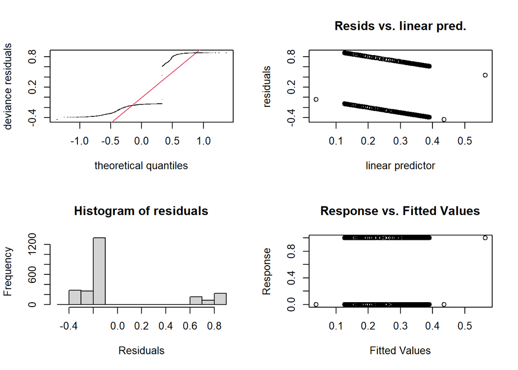

```
#>
#> Method: REML   Optimizer: outer newton
#> full convergence after 8 iterations.
#> Gradient range [-0.0001161048,5.614021e-05]
#> (score 1130.261 & scale 0.1513132).
#> Hessian positive definite, eigenvalue range [0.0001160758,1174.506].
#> Model rank =  51 / 51
#>
#> Basis dimension (k) checking results. Low p-value (k-index<1) may
#> indicate that k is too low, especially if edf is close to k'.
#>
#>                         k'   edf k-index p-value
#> s(poi$gluc)          24.00  5.00    0.37  <2e-16 ***
#> s(poi$gluc):poi$diab 25.00  2.08    0.37  <2e-16 ***
#> ---
#> Signif. codes:  0 '***' 0.001 '**' 0.01 '*' 0.05 '.' 0.1 ' ' 1
```

```r
gam.check(gam3)
```

- Compara este modelo con el modelo sin interacción, ¿con cuál te quedas?

```r
poi <- read.csv("C:/Users/dgoma/Downloads/POI.txt", sep="")
library(mgcv)
gam1 <- gam(poi$poi ~ poi$diab + s(poi$gluc,k=25,bs="ps"),method="REML", select=TRUE)
gam3 <- gam(poi$poi ~ poi$diab + s(poi$gluc,k=25,bs="ps") +
              s(poi$gluc,k=25,bs="ps",by=poi$diab),method="REML",select=TRUE)
anova(gam1,gam3,test="F")
```

```
#> Analysis of Deviance Table
#>
#> Model 1: poi$poi ~ poi$diab + s(poi$gluc, k = 25, bs = "ps")
#> Model 2: poi$poi ~ poi$diab + s(poi$gluc, k = 25, bs = "ps") + s(poi$gluc,
#>     k = 25, bs = "ps", by = poi$diab)
#>   Resid. Df Resid. Dev     Df Deviance     F  Pr(>F)
#> 1    2341.9     355.82
#> 2    2337.6     354.36 4.2474   1.4531 2.261 0.05641 .
#> ---
#> Signif. codes:  0 '***' 0.001 '**' 0.01 '*' 0.05 '.' 0.1 ' ' 1
```

```r
# Es mejor el modelo con interacción porque los residuos son menores.
```

3. En base al mejor modelo anterior, evaluar el posible efecto la edad (`age`) y el sexo (`gender`) sobre la presencia de infección post-operatoria (`poi`).
- Incorpora la variable edad y compara el nuevo modelo con el anterior

```r
poi <- read.csv("C:/Users/dgoma/Downloads/POI.txt", sep="")
library(mgcv)
gam1 <- gam(poi$poi ~ poi$diab + s(poi$gluc,k=25,bs="ps"),method="REML", select=TRUE)
gam4 <- gam(poi$poi ~ poi$diab + s(poi$gluc,k=25,bs="ps") + s(poi$age,k=25,bs="ps"),method="REML", select=TRUE)
summary(gam4)
```

```
#>
#> Family: gaussian
#> Link function: identity
#>
#> Formula:
#> poi$poi ~ poi$diab + s(poi$gluc, k = 25, bs = "ps") + s(poi$age,
#>     k = 25, bs = "ps")
#>
#> Parametric coefficients:
#>             Estimate Std. Error t value Pr(>|t|)
#> (Intercept) 0.196284   0.008278  23.711   <2e-16 ***
#> poi$diab    0.017866   0.036861   0.485    0.628
#> ---
#> Signif. codes:  0 '***' 0.001 '**' 0.01 '*' 0.05 '.' 0.1 ' ' 1
#>
#> Approximate significance of smooth terms:
#>                edf Ref.df     F p-value
#> s(poi$gluc) 4.9976     24 3.010  <2e-16 ***
#> s(poi$age)  0.9936     24 1.558  <2e-16 ***
#> ---
#> Signif. codes:  0 '***' 0.001 '**' 0.01 '*' 0.05 '.' 0.1 ' ' 1
#>
#> R-sq.(adj) =  0.0569   Deviance explained = 5.97%
#> -REML = 1115.7  Scale est. = 0.14945   n = 2351
```

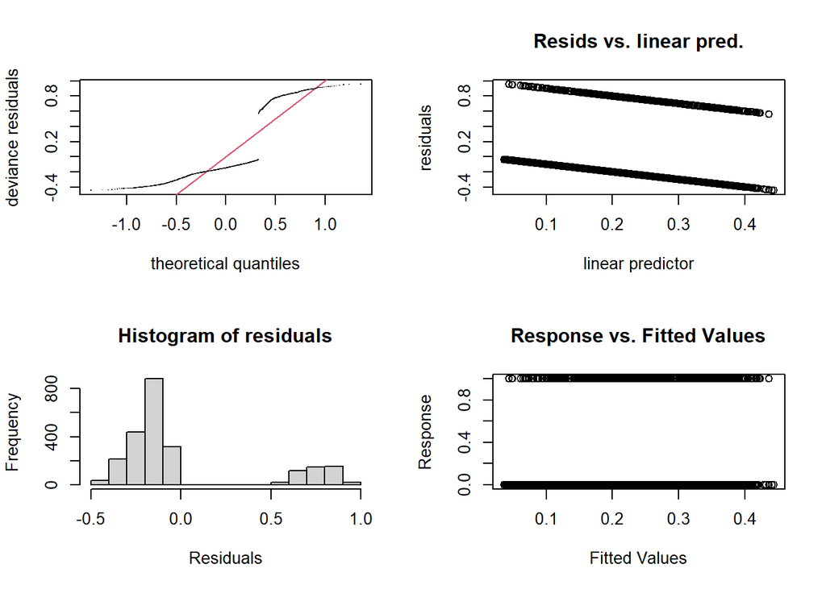

```
#>
#> Method: REML   Optimizer: outer newton
#> full convergence after 10 iterations.
#> Gradient range [-0.0005585502,0.003980782]
#> (score 1115.664 & scale 0.149455).
#> Hessian positive definite, eigenvalue range [6.48823e-05,1174.502].
#> Model rank =  50 / 50
#>
#> Basis dimension (k) checking results. Low p-value (k-index<1) may
#> indicate that k is too low, especially if edf is close to k'.
#>
#>                 k'    edf k-index p-value
#> s(poi$gluc) 24.000  4.998    0.38  <2e-16 ***
#> s(poi$age)  24.000  0.994    0.23  <2e-16 ***
#> ---
#> Signif. codes:  0 '***' 0.001 '**' 0.01 '*' 0.05 '.' 0.1 ' ' 1
anova(gam1,gam4,test="F")
#> Analysis of Deviance Table
#>
#> Model 1: poi$poi ~ poi$diab + s(poi$gluc, k = 25, bs = "ps")
#> Model 2: poi$poi ~ poi$diab + s(poi$gluc, k = 25, bs = "ps") + s(poi$age,
#>     k = 25, bs = "ps")
#>   Resid. Df Resid. Dev     Df Deviance      F   Pr(>F)
#> 1    2341.9     355.82
#> 2    2340.3     350.17 1.5875   5.6422 23.781 3.41e-09 ***
#> ---
#> Signif. codes:  0 '***' 0.001 '**' 0.01 '*' 0.05 '.' 0.1 ' ' 1
AIC(gam1,gam4)
#>             df      AIC
#> gam1  8.721048 2250.178
#> gam4 10.285420 2215.728

# El modelo que incluye la variable edad es mejor porque su residual es menor
```

```r
gam.check(gam4)
```

- Ajusta el modelo incorporando las variables edad y sexo. ¿Qué conclusiones extraes?

```r
poi <- read.csv("C:/Users/dgoma/Downloads/POI.txt", sep="")
library(mgcv)
gam1 <- gam(poi$poi ~ poi$diab + s(poi$gluc,k=25,bs="ps"),method="REML", select=TRUE)
gam4 <- gam(poi$poi ~ poi$diab + s(poi$gluc,k=25,bs="ps") + s(poi$age,k=25,bs="ps"),method="REML", select=TRUE)
gam5 <- gam(poi$poi ~ poi$diab + s(poi$gluc,k=25,bs="ps") + s(poi$age,k=25,bs="ps") + poi$gender,method="REML", select=TRUE)
summary(gam5)
```

```
#>
#> Family: gaussian
#> Link function: identity
#>
#> Formula:
#> poi$poi ~ poi$diab + s(poi$gluc, k = 25, bs = "ps") + s(poi$age,
#>     k = 25, bs = "ps") + poi$gender
#>
#> Parametric coefficients:
#>             Estimate Std. Error t value Pr(>|t|)
#> (Intercept)  0.16062    0.01143  14.058  < 2e-16 ***
#> poi$diab     0.01942    0.03671   0.529    0.597
#> poi$gender   0.07247    0.01607   4.509 6.83e-06 ***
#> ---
#> Signif. codes:  0 '***' 0.001 '**' 0.01 '*' 0.05 '.' 0.1 ' ' 1
#>
#> Approximate significance of smooth terms:
#>                edf Ref.df     F p-value
#> s(poi$gluc) 4.9911     24 2.777  <2e-16 ***
#> s(poi$age)  0.9813     24 1.736  <2e-16 ***
#> ---
#> Signif. codes:  0 '***' 0.001 '**' 0.01 '*' 0.05 '.' 0.1 ' ' 1
#>
#> R-sq.(adj) =  0.0647   Deviance explained = 6.78%
#> -REML = 1108.8  Scale est. = 0.14823   n = 2351
```

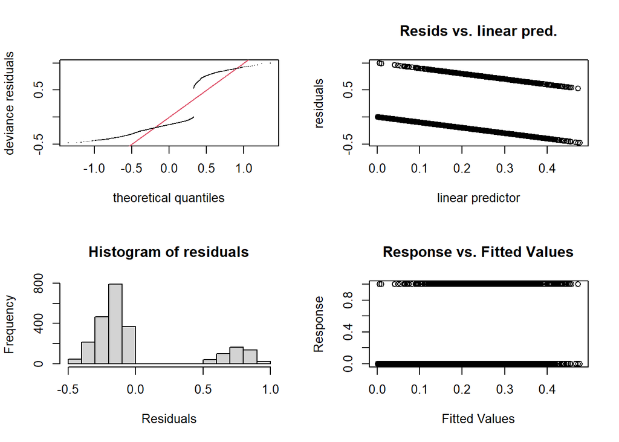

```
#>
#> Method: REML   Optimizer: outer newton
#> full convergence after 11 iterations.
#> Gradient range [-0.0002842151,0.001788278]
#> (score 1108.752 & scale 0.1482305).
#> Hessian positive definite, eigenvalue range [1.970872e-05,1174.004].
#> Model rank =  51 / 51
#>
#> Basis dimension (k) checking results. Low p-value (k-index<1) may
#> indicate that k is too low, especially if edf is close to k'.
#>
#>                 k'    edf k-index p-value
#> s(poi$gluc) 24.000  4.991    0.39  <2e-16 ***
#> s(poi$age)  24.000  0.981    0.24  <2e-16 ***
#> ---
#> Signif. codes:  0 '***' 0.001 '**' 0.01 '*' 0.05 '.' 0.1 ' ' 1
anova(gam1,gam4,gam5,test="F")
#> Analysis of Deviance Table
#>
#> Model 1: poi$poi ~ poi$diab + s(poi$gluc, k = 25, bs = "ps")
#> Model 2: poi$poi ~ poi$diab + s(poi$gluc, k = 25, bs = "ps") + s(poi$age,
#>     k = 25, bs = "ps")
#> Model 3: poi$poi ~ poi$diab + s(poi$gluc, k = 25, bs = "ps") + s(poi$age,
#>     k = 25, bs = "ps") + poi$gender
#>   Resid. Df Resid. Dev      Df Deviance      F    Pr(>F)
#> 1    2341.9     355.82
#> 2    2340.3     350.17 1.58747   5.6422 23.978 2.920e-09 ***
#> 3    2339.9     347.16 0.42389   3.0143 47.972 1.404e-06 ***
#> ---
#> Signif. codes:  0 '***' 0.001 '**' 0.01 '*' 0.05 '.' 0.1 ' ' 1
AIC(gam1,gam4,gam5)
#>             df      AIC
#> gam1  8.721048 2250.178
#> gam4 10.285420 2215.728
#> gam5 10.727367 2196.287

# El modelo que incluye las variable edad y sexo es mejor porque su residual es menor
```

```r
gam.check(gam5)
```

- Ajusta el modelo incorporando la interacción entre edad y sexo. ¿Hay interacción?. ¿Mejora el modelo?

```r
poi <- read.csv("C:/Users/dgoma/Downloads/POI.txt", sep="")
library(mgcv)
gam5 <- gam(poi$poi ~ poi$diab + s(poi$gluc,k=25,bs="ps") + s(poi$age,k=25,bs="ps") + poi$gender,method="REML", select=TRUE)
gam6 <- gam(poi$poi ~ poi$diab + s(poi$gluc,k=25,bs="ps") + s(poi$age,k=25,bs="ps") + poi$gender + s(poi$age,k=25,bs="ps",by=poi$gender),method="REML",select=TRUE)
summary(gam6)
```

```
#>
#> Family: gaussian
#> Link function: identity
#>
#> Formula:
#> poi$poi ~ poi$diab + s(poi$gluc, k = 25, bs = "ps") + s(poi$age,
#>     k = 25, bs = "ps") + poi$gender + s(poi$age, k = 25, bs = "ps",
#>     by = poi$gender)
#>
#> Parametric coefficients:
#>             Estimate Std. Error t value Pr(>|t|)
#> (Intercept)  0.16062    0.01143  14.058  < 2e-16 ***
#> poi$diab     0.01942    0.03671   0.529    0.597
#> poi$gender   0.07247    0.01608   4.508 6.87e-06 ***
#> ---
#> Signif. codes:  0 '***' 0.001 '**' 0.01 '*' 0.05 '.' 0.1 ' ' 1
#>
#> Approximate significance of smooth terms:
#>                             edf Ref.df     F p-value
#> s(poi$gluc)           4.9911949     24 2.777  <2e-16 ***
#> s(poi$age)            0.9852071     24 1.736  <2e-16 ***
#> s(poi$age):poi$gender 0.0004207     24 0.000    0.83
#> ---
#> Signif. codes:  0 '***' 0.001 '**' 0.01 '*' 0.05 '.' 0.1 ' ' 1
#>
#> R-sq.(adj) =  0.0647   Deviance explained = 6.78%
#> -REML = 1108.8  Scale est. = 0.14823   n = 2351
```

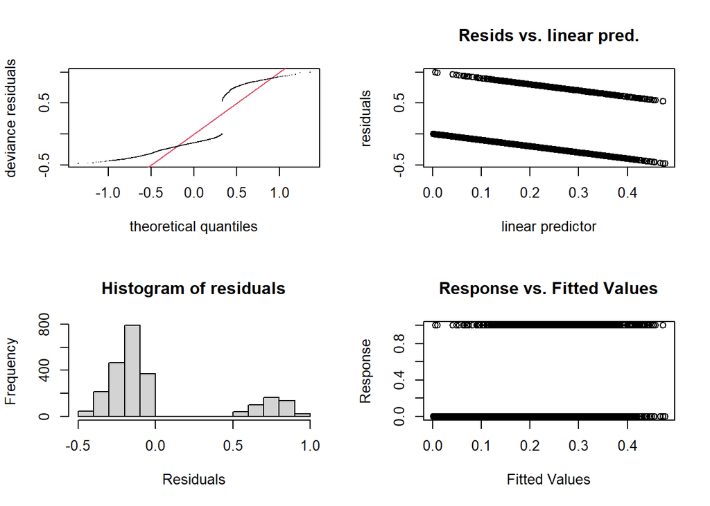

```
#>
#> Method: REML   Optimizer: outer newton
#> full convergence after 11 iterations.
#> Gradient range [-0.0005282077,0.002965604]
#> (score 1108.752 & scale 0.1482304).
#> Hessian positive definite, eigenvalue range [5.787746e-05,1174.003].
#> Model rank =  76 / 76
#>
#> Basis dimension (k) checking results. Low p-value (k-index<1) may
#> indicate that k is too low, especially if edf is close to k'.
#>
#>                             k'      edf k-index p-value
#> s(poi$gluc)           2.40e+01 4.99e+00    0.39  <2e-16 ***
#> s(poi$age)            2.40e+01 9.85e-01    0.24  <2e-16 ***
#> s(poi$age):poi$gender 2.50e+01 4.21e-04    0.24  <2e-16 ***
#> ---
#> Signif. codes:  0 '***' 0.001 '**' 0.01 '*' 0.05 '.' 0.1 ' ' 1
anova(gam5,gam6,test="F")
#> Analysis of Deviance Table
#>
#> Model 1: poi$poi ~ poi$diab + s(poi$gluc, k = 25, bs = "ps") + s(poi$age,
#>     k = 25, bs = "ps") + poi$gender
#> Model 2: poi$poi ~ poi$diab + s(poi$gluc, k = 25, bs = "ps") + s(poi$age,
#>     k = 25, bs = "ps") + poi$gender + s(poi$age, k = 25, bs = "ps",
#>     by = poi$gender)
#>   Resid. Df Resid. Dev      Df  Deviance      F Pr(>F)
#> 1    2339.9     347.16
#> 2    2339.7     347.16 0.15994 0.0010514 0.0443 0.3366
AIC(gam5,gam6)
#>            df      AIC
#> gam5 10.72737 2196.287
#> gam6 10.88296 2196.591

# El modelo no mejora incorporando la interacción entre edad y sexo. No hay interaccion significativa.
```

```r
gam.check(gam6)
```

- Finalmente ajusta un modelo incorporando la interacción de la glucosa y la edad. Obtén un resumen del modelo y los gráficos de los efectos. ¿Hay evidencias que sugieran la presencia de interacción?

```r
poi <- read.csv("C:/Users/dgoma/Downloads/POI.txt", sep="")
library(mgcv)
gam5 <- gam(poi$poi ~ poi$diab + s(poi$gluc,k=25,bs="ps") + s(poi$age,k=25,bs="ps") + poi$gender,method="REML", select=TRUE)
gam7 <- gam(poi$poi ~ poi$diab + s(poi$gluc,k=25,bs="ps") + s(poi$age,k=25,bs="ps") + poi$gender + s(poi$age,k=25,bs="ps",by=poi$gluc),method="REML",select=TRUE)
summary(gam7)
```

```
#>
#> Family: gaussian
#> Link function: identity
#>
#> Formula:
#> poi$poi ~ poi$diab + s(poi$gluc, k = 25, bs = "ps") + s(poi$age,
#>     k = 25, bs = "ps") + poi$gender + s(poi$age, k = 25, bs = "ps",
#>     by = poi$gluc)
#>
#> Parametric coefficients:
#>             Estimate Std. Error t value Pr(>|t|)
#> (Intercept)  0.16689    0.01257  13.274  < 2e-16 ***
#> poi$diab     0.02444    0.03693   0.662    0.508
#> poi$gender   0.07247    0.01607   4.511 6.78e-06 ***
#> ---
#> Signif. codes:  0 '***' 0.001 '**' 0.01 '*' 0.05 '.' 0.1 ' ' 1
#>
#> Approximate significance of smooth terms:
#>                        edf Ref.df     F p-value
#> s(poi$gluc)         4.9872     24 2.765  <2e-16 ***
#> s(poi$age)          0.9752     24 1.583  <2e-16 ***
#> s(poi$age):poi$gluc 1.0639     25 0.098  0.0875 .
#> ---
#> Signif. codes:  0 '***' 0.001 '**' 0.01 '*' 0.05 '.' 0.1 ' ' 1
#>
#> R-sq.(adj) =  0.0657   Deviance explained = 6.93%
#> -REML = 1108.3  Scale est. = 0.14807   n = 2351
```

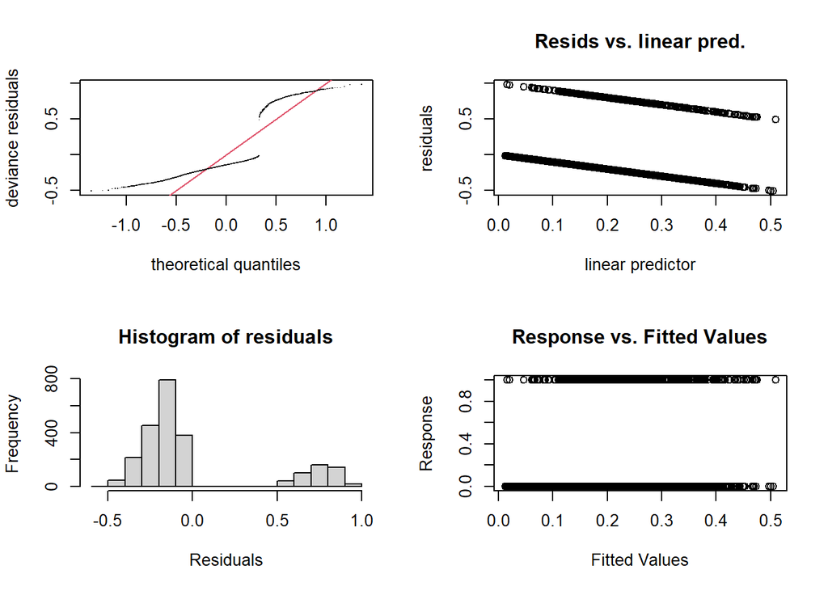

```
#>
#> Method: REML   Optimizer: outer newton
#> full convergence after 16 iterations.
#> Gradient range [-0.0003206013,0.0002389362]
#> (score 1108.311 & scale 0.1480677).
#> Hessian positive definite, eigenvalue range [2.878028e-06,1174.006].
#> Model rank =  76 / 76
#>
#> Basis dimension (k) checking results. Low p-value (k-index<1) may
#> indicate that k is too low, especially if edf is close to k'.
#>
#>                         k'    edf k-index p-value
#> s(poi$gluc)         24.000  4.987    0.39  <2e-16 ***
#> s(poi$age)          24.000  0.975    0.24  <2e-16 ***
#> s(poi$age):poi$gluc 25.000  1.064    0.24  <2e-16 ***
#> ---
#> Signif. codes:  0 '***' 0.001 '**' 0.01 '*' 0.05 '.' 0.1 ' ' 1

# No hay evidencias que sugeren la presencia de interacción de la glucosa y la edad
```

```r
gam.check(gam7)
```